**Jennifer Kelley** - January 7, 2026

# Week 1 Assignment

## Story 1 -- Student Test Scores

A group of high school students took a math exam, and the teacher wants to analyze the performance to identify areas where students struggle.

The scores of the students are:

- 78, 85, 92, 56, 69, 73, 88, 91, 45, 82, 67, 72, 93, 54, 77, 88, 60, 95, 81, 79, 90, 67, 65, 77, 71, 81, 85, 88, 79, 66, 72, 89, 64, 82, 79, 94, 70, 84, 66, 73

Create a histogram of scores, identify outliers, and calculate mean, median, mode, range, variance, and standard deviation.

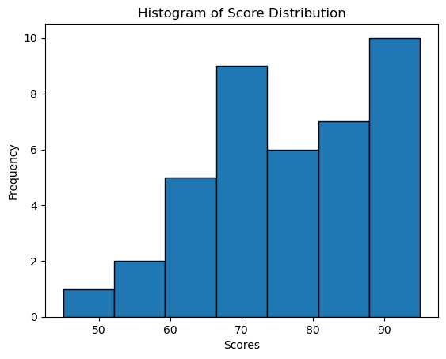

```python
import matplotlib.pyplot as plt

student_scores = [
    78, 85, 92, 56, 69, 73, 88, 91, 45, 82, 67, 72, 93, 54, 77, 88, 60, 95, 81, 79, 90, 67, 65, 77, 71, 81, 85, 88, 79, 66, 72, 89, 64, 82, 79, 94, 70, 84, 66, 73]

plt.hist(student_scores, bins=7, edgecolor='black')
plt.title('Histogram of Score Distribution')
plt.xlabel('Scores')
plt.ylabel('Frequency')
plt.show()
```

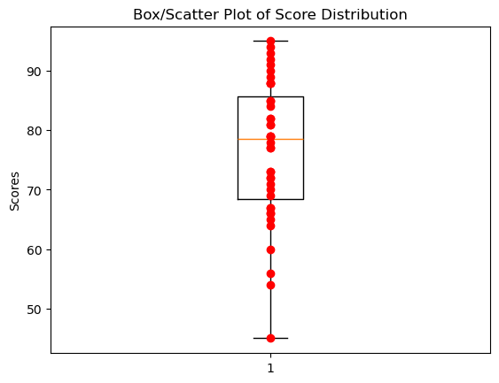

```python
plt.boxplot(student_scores)
plt.title('Box/Scatter Plot of Score Distribution')
plt.ylabel('Scores')

plt.scatter([1]*len(student_scores), student_scores, color='red', zorder=5)
plt.show()
```

### *Conclusion*

```python
import numpy as np
from collections import Counter

mea = np.mean(student_scores)
med = np.median(student_scores)
mod = Counter(student_scores).most_common(1)[0][0]
ran = np.max(student_scores) - np.min(student_scores)
var = np.var(student_scores)
std = np.std(student_scores)

print(f'\n Mean: {mea} \n Median: {med} \n Mode: {mod} \n' +
      f'\n Range: {ran} \n Variance: {var} \n Standard Deviation: {std} \n')
```

```
 Mean: 76.675
 Median: 78.5
 Mode: 88

 Range: 50
 Variance: 137.56937499999998
 Standard Deviation: 11.728997186460571
```

## Story 2 -- Employee Performance Ratings

A company conducts annual performance reviews, and HR collects ratings to determine the overall employee satisfaction and identify top performers.

The employee performance ratings (1-5 scale) are:

- 3, 4, 5, 2, 3, 5, 4, 2, 3, 4, 5, 1, 3, 5, 4, 2, 4, 3, 3, 5, 4, 3, 2, 4, 5

Create a pie chart of ratings distribution and calculate the measures of center and spread.

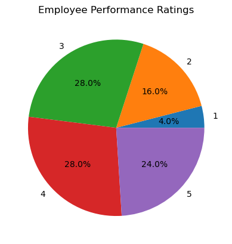

```python
import pandas as pd

ratings = [3, 4, 5, 2, 3, 5, 4, 2, 3, 4, 5, 1, 3, 5, 4, 2, 4, 3, 3, 5, 4, 3, 2, 4, 5]

bins = [1, 2, 3, 4, 5, 6]
labels = ['1', '2', '3', '4', '5']

rating_groups = pd.cut(ratings, bins=bins, labels=labels, right=False)
freq_table = rating_groups.value_counts().sort_index()

plt.pie(freq_table, autopct='%1.1f%%', labels=labels)
plt.title('Employee Performance Ratings')
plt.show()
```

```python
mea = np.mean(ratings)
med = np.median(ratings)
mod = Counter(ratings).most_common(1)[0][0]
ran = np.max(ratings) - np.min(ratings)
var = np.var(ratings)
std = np.std(ratings)

print(f'\n Measures of Center' +
      f'\n Mean: {mea} \n Median: {med} \n Mode: {mod} \n' +
      f'\n Measures of Spread' +
      f'\n Range: {ran} \n Variance: {var} \n Standard Deviation: {std} \n')
```

```
 Measures of Center
 Mean: 3.52
 Median: 4.0
 Mode: 3

 Measures of Spread
 Range: 4
 Variance: 1.2896
 Standard Deviation: 1.1356055653262713
```

## Story 3 -- Customer Satisfaction Ratings

An online service company surveys its customers about their satisfaction level to improve service quality.

- 3, 4, 5, 2, 4, 3, 5, 1, 4, 2, 3, 4, 5, 2, 3, 4, 5, 3, 2, 4

Create a histogram of satisfaction ratings, calculate the mean, median, and mode, and analyze the spread using variance and standard deviation.

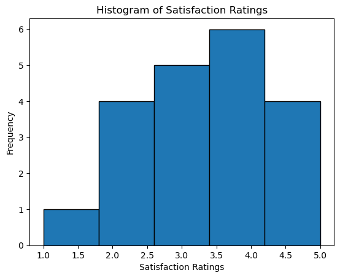

```python
satisfaction_ratings = [3, 4, 5, 2, 4, 3, 5, 1, 4, 2, 3, 4, 5, 2, 3, 4, 5, 3, 2, 4]

plt.hist(satisfaction_ratings, bins=5, edgecolor='black')
plt.title('Histogram of Satisfaction Ratings')
plt.xlabel('Satisfaction Ratings')
plt.ylabel('Frequency')
plt.show()
```

```python
mea = np.mean(student_scores)
med = np.median(student_scores)
mod = Counter(student_scores).most_common(1)[0][0]

print(f'\n Mean: {mea} \n Median: {med} \n Mode: {mod} \n')
```

[output not shown]

```python
var = np.var(student_scores)
std = np.std(student_scores)

print(f'\n Variance: {var} \n Standard Deviation: {std} \n')
```

[output not shown]

## Story 4 -- Traffic Accident Data

A city department collects data on traffic accidents to identify hotspots and improve safety measures.

| Accident IDs | 1 | 2 | 3 | 4 | 5 | 6 | 7 | 8 | 9 | 10 | 11 | 12 | 13 | 14 | 15 |
| --- | --- | --- | --- | --- | --- | --- | --- | --- | --- | --- | --- | --- | --- | --- | --- |
| Severity | 3 | 2 | 4 | 1 | 3 | 5 | 4 | 2 | 3 | 5 | 1 | 4 | 2 | 5 | 3 |

Use Python to create a pie chart to visualize the distribution of accident severity, analyze the data for trends in severity, and calculate measures of center and spread.

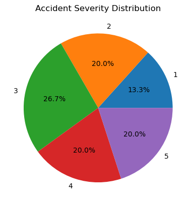

```python
accident_ids = [1, 2, 3, 4, 5, 6, 7, 8, 9, 10, 11, 12, 13, 14, 15]
severity = [3, 2, 4, 1, 3, 5, 4, 2, 3, 5, 1, 4, 2, 5, 3]

bins = [1, 2, 3, 4, 5, 6]
labels = ['1', '2', '3', '4', '5']

severity_groups = pd.cut(severity, bins=bins, labels=labels, right=False)
freq_table = severity_groups.value_counts().sort_index()

plt.pie(freq_table, autopct='%1.1f%%', labels=labels)
plt.title('Accident Severity Distribution')
plt.show()
```

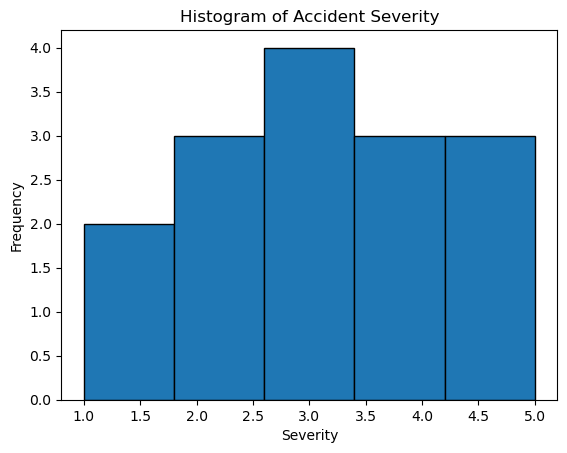

```python
plt.hist(severity, bins=5, edgecolor='black')
plt.title('Histogram of Accident Severity')
plt.xlabel('Severity')
plt.ylabel('Frequency')
plt.show()
```

### *Conclusions*

From this histogram we can see that the fewest accidents are of the least severity, while most accidents are of middle severity.

```python
mea = np.mean(severity)
med = np.median(severity)
mod = Counter(severity).most_common(1)[0][0]
ran = np.max(severity) - np.min(severity)
var = np.var(severity)
std = np.std(severity)

print(f'\n Measures of Center' +
      f'\n Mean: {mea} \n Median: {med} \n Mode: {mod} \n' +
      f'\n Measures of Spread' +
      f'\n Range: {ran} \n Variance: {var} \n Standard Deviation: {std} \n')
```

```
 Measures of Center
 Mean: 3.1333333333333333
 Median: 3.0
 Mode: 3

 Measures of Spread
 Range: 4
 Variance: 1.7155555555555557
 Standard Deviation: 1.3097921802925667
```

## Story 5 -- Online Course Enrollments

An online learning platform tracks enrollments in its courses to evaluate the demand for different subjects.

| Course | Python Programming | Data Science | Web Development | Machine Learning | Digital Marketing | Graphic Design | Cybersecurity | AI Basics | Business Analytics | JavaScript Essentials |
| --- | --- | --- | --- | --- | --- | --- | --- | --- | --- | --- |
| Enrollments | 320 | 450 | 380 | 500 | 310 | 280 | 360 | 400 | 390 | 410 |
| Course | Cloud Computing | Excel for Beginners | Project Management | Python for Data Analysis | UIUX Design | Finance Fundamentals | SQL Basics | Programming | Public Speaking | SEO Optimization |
| Enrollments | 300 | 370 | 420 | 460 | 350 | 330 | 340 | 310 | 295 | 375 |

Use Python to create a bar graph to visualize enrollments by course, identify any trends in course popularity, and calculate the mean, median, and mode of enrollments.

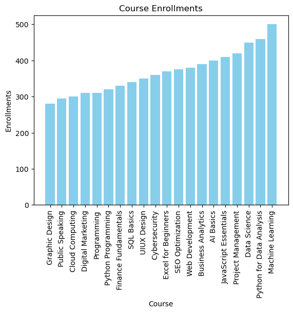

```python
courses = [
    "Python Programming", "Data Science", "Web Development", "Machine Learning",
    "Digital Marketing", "Graphic Design", "Cybersecurity", "AI Basics",
    "Business Analytics", "JavaScript Essentials", "Cloud Computing",
    "Excel for Beginners", "Project Management", "Python for Data Analysis",
    "UIUX Design", "Finance Fundamentals", "SQL Basics", "Programming",
    "Public Speaking", "SEO Optimization"
]
enrollments = [
    320, 450, 380, 500, 310, 280, 360, 400, 390, 410,
    300, 370, 420, 460, 350, 330, 340, 310, 295, 375
]

df = pd.DataFrame({'Courses': courses, 'Enrollments': enrollments})
df = df.sort_values('Enrollments')

courses = df['Courses'].to_list()
enrollments = df['Enrollments'].to_list()

plt.bar(courses, enrollments, color='skyblue')
plt.title('Course Enrollments')
plt.xlabel('Course')
plt.xticks(rotation=90)
plt.ylabel('Enrollments')
plt.show()
```

### *Conclusions*

Based on the above graph the 3 most popular classes are data science classes. It appears based on the course titles that introductory and less specialized classes are amoung the least popular.

```python
mea = np.mean(enrollments)
med = np.median(enrollments)
mod = Counter(enrollments).most_common(1)[0][0]

print(f'\n Mean: {mea} \n Median: {med} \n Mode: {mod} \n')
```

```
 Mean: 367.5
 Median: 365.0
 Mode: 310
```